# Getting Started With ggplot2

## Facet Graphs

Sometimes you may have a complicated graphic that takes too long for your audience to digest. For example, remember our first graph? The one that showed the relationship between flipper length and body mass? Just in case I’m printing it again here:

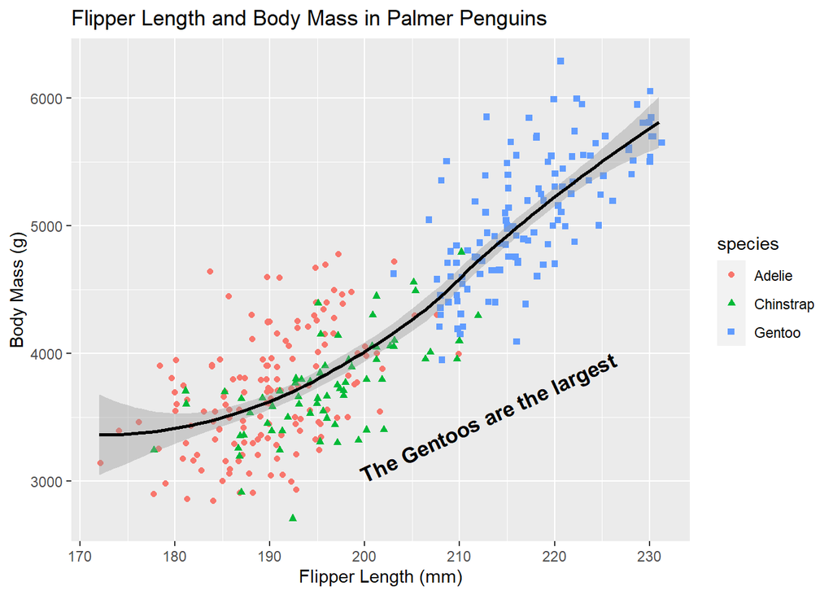

In this graph, there is a clear correlation between flipper length and body mass. The longer the flippers, the larger the penguin is- and this ratio holds true across all the penguin species. There is, however, a large disparity between the actual *sizes* of all three penguins, and it’s possible audience members might get distracted by this. So to make the graph easier to understand, we can use the facet_wrap function:

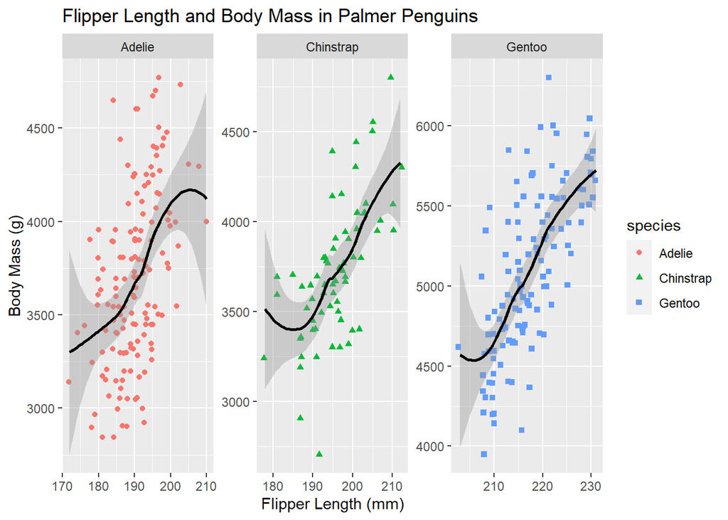

```r
ggplot(data=penguins) +
  geom_jitter(mapping=aes(x=flipper_length_mm,y=body_mass_g,color=species,shape=species))+
  geom_smooth(mapping=aes(x=flipper_length_mm,y=body_mass_g),
              color="black")+
  facet_wrap(~species,scales="free")+
  labs(title="Flipper Length and Body Mass in Palmer Penguins",
       x="Flipper Length (mm)",
       y="Body Mass (g)")
```

There. Now all the penguins have been divided out by species. I’ve left the code in so you can see how it’s done. If you’re analyzing something **really** complicated you can even use the facet_grid function to divide your graph into even more pieces! We’ll look at our penguin populations again, this time taking sex into account as well:

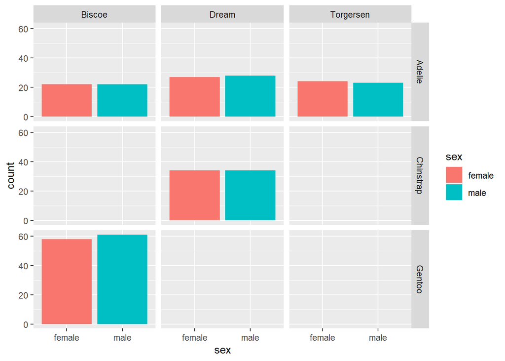

```r
penguins_2 <- penguins %>%
  na.omit(penguins$sex)

ggplot(data=penguins_2)+
  geom_bar(mapping=aes(x=sex,fill=sex))+
  facet_grid(species~island)
```

Hmm, looks like we have a fairly good sample here, with roughly equal numbers of males and females of each species represented. Notice in the code the first argument splits the chart horizontally, and the second splits the chart vertically. Notice also, I had to remove several na values from the sex column before I could graph it, using a tidyverse pipe.

## ggplot2 And dplyr Combined

I’m glad we had to use the tidyverse pipe above, because it brings up a good point: *you can combine packages with ggplot2*!! This is very exciting. It means we can first get a subset of our data with dplyr and then visualize *just that subset* with ggplot2. For example, it just occurred to me, I don’t think I know whether Gentoo males or females are bigger. I’ve watched all of Blue Planet probably 10 times and somehow this fact has escaped me. I’ve picked Gentoo here, but you could really filter for anything.

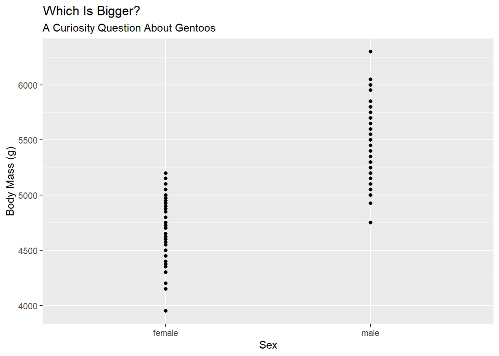

```r
library(dplyr)
penguins_Gentoo <- penguins_2 %>%
  filter(species=="Gentoo")

ggplot(data=penguins_Gentoo)+
  geom_point(mapping=aes(x=sex,y=body_mass_g))+
  labs(title="Which Is Bigger?",
       subtitle= "A Curiosity Question About Gentoos",
       x="Sex",
       y="Body Mass (g)")
```

Ah ha! The males are bigger! Good to know. Notice I used the dataframe with the dropped na values from last time, to simplify the chart. I decided this was okay because there are only 4 na values here, which is not a significant amount. Also, *remember to **load** dplyr before attempting a filter-graph sequence*!! Otherwise it won’t work. You cannot take functions out of a package you haven’t opened yet. I cannot stress this enough. Asking a computer to do something like that will make it extremely, almost violently confused.

## Conclusion

Alright, that’s it! I hope you enjoyed this brief survey of some of the wonders of ggplot2! We’ve only scratched the surface of what is possible. Next up, geom_area, geom_histogram, even geom_map! For more in depth guidance on how to install and use ggplot2 yourself check out the official instructions [here](https://ggplot2.tidyverse.org/).